# KCell

A `KCell` is like an empty canvas, where you can add polygons and instances to other Cells and ports (which is used to connect to other cells)

In KLayout geometries are in datatabase units (dbu) or microns. GDS uses an integer grid as a basis for geometries. The default is `0.001`, i.e. 1nm grid size (0.001 microns)

- `Point`, `Box`, `Polygon`, `Edge`, `Region` are in dbu
- `DPoint`, `DBox`, `DPolygon`, `DEdge` are in microns

Most Shape types are available as microns and dbu parts. They can be converted with `<ShapeTypeDBU>.to_dtype(dbu)` to microns and with `<ShapeTypeMicrons>.to_itype(dbu)` where `dbu` is the the conversion of one database unit to microns. Alternatively they can be converted with `c.kcl.to_um(<ShapeTypeDBU>)` or `c.kcl.to_dbu(<ShapeTypeMicrons>)` where `c.kcl` is the KCell and `kcl` is the `KCLayout` which owns the KCell.

Imports: It imports the necessary libraries: kfactory for layout creation and numpy for numerical operations LayerInfos Class: In chip fabrication, the design is built up layer by layer. Each layer corresponds to a specific material or process step (e.g., silicon, metal, oxide). This class creates human-readable names (WG for waveguide, CLAD for cladding) and maps them to the GDS layer numbers ((1, 0), (4, 0))

```python
import kfactory as kf
import numpy as np
```

import kfactory as kf import numpy as np

```python
# Define Layers

class LayerInfos(kf.LayerInfos):
    WG: kf.kdb.LayerInfo = kf.kdb.LayerInfo(1,0)
    WGEX: kf.kdb.LayerInfo = kf.kdb.LayerInfo(2,0) # WG Exclude
    CLAD: kf.kdb.LayerInfo = kf.kdb.LayerInfo(4,0) # cladding
    FLOORPLAN: kf.kdb.LayerInfo = kf.kdb.LayerInfo(10,0)

# Make the layout object aware of the new layers:
LAYER = LayerInfos()
kf.kcl.infos = LAYER
```

# Define Layers class LayerInfos(kf.LayerInfos): WG: kf.kdb.LayerInfo = kf.kdb.LayerInfo(1,0) WGEX: kf.kdb.LayerInfo = kf.kdb.LayerInfo(2,0) # WG Exclude CLAD: kf.kdb.LayerInfo = kf.kdb.LayerInfo(4,0) # cladding FLOORPLAN: kf.kdb.LayerInfo = kf.kdb.LayerInfo(10,0) # Make the layout object aware of the new layers: LAYER = LayerInfos() kf.kcl.infos = LAYER

```python
# Create a blank cell (essentially an empty GDS cell with some special features)
c = kf.KCell()
```

# Create a blank cell (essentially an empty GDS cell with some special features) c = kf.KCell()

```python
# Create and add a polygon from separate lists of x points and y points
# (Can also be added like [(x1,y1), (x2,y2), (x3,y3), ... ]
poly1 = kf.kdb.DPolygon(
    [
        kf.kdb.DPoint(-8, -6),
        kf.kdb.DPoint(6, 8),
        kf.kdb.DPoint(7, 17),
        kf.kdb.DPoint(9, 5),
    ]
)
```

# Create and add a polygon from separate lists of x points and y points # (Can also be added like [(x1,y1), (x2,y2), (x3,y3), ... ] poly1 = kf.kdb.DPolygon( [ kf.kdb.DPoint(-8, -6), kf.kdb.DPoint(6, 8), kf.kdb.DPoint(7, 17), kf.kdb.DPoint(9, 5), ] )

```python
c.shapes(c.kcl.find_layer(1, 0)).insert(poly1)
```

c.shapes(c.kcl.find_layer(1, 0)).insert(poly1)

```
polygon (-8000,-6000;6000,8000;7000,17000;9000,5000)
```

```python
c.show()  # show in KLayout
c.plot()
```

c.show() # show in KLayout c.plot()

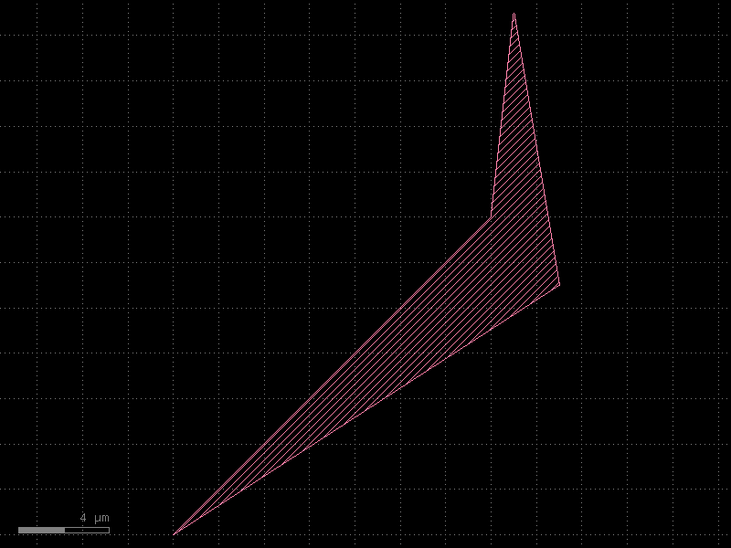

**Exercise** :

Make a cell similar to the one above that has a second polygon in layer (2, 0)

**Solution** :

```python
c = kf.KCell()
points = np.array([(-8, -6), (6, 8), (7, 17), (9, 5)])
poly = kf.polygon_from_array(points)
c.shapes(c.kcl.find_layer(1, 0)).insert(poly1)
c.shapes(c.kcl.find_layer(2, 0)).insert(poly1)
c

# kf.kdb.TextGenerator: This creates a text object. The text "Hello!" is converted into a set of polygons that can be fabricated.
# kf.kdb.DBox(...): This creates a simple rectangle (a box).
# This box is defined by the coordinates of its lower-left corner (-2.5, -5) and upper-right corner (2.5, 5).
# Like before, these shapes are then inserted into specific layers in the cell c.
```

c = kf.KCell() points = np.array([(-8, -6), (6, 8), (7, 17), (9, 5)]) poly = kf.polygon_from_array(points) c.shapes(c.kcl.find_layer(1, 0)).insert(poly1) c.shapes(c.kcl.find_layer(2, 0)).insert(poly1) c # kf.kdb.TextGenerator: This creates a text object. The text "Hello!" is converted into a set of polygons that can be fabricated. # kf.kdb.DBox(...): This creates a simple rectangle (a box). # This box is defined by the coordinates of its lower-left corner (-2.5, -5) and upper-right corner (2.5, 5). # Like before, these shapes are then inserted into specific layers in the cell c.

[figure not shown]

```python
c = kf.KCell()
textgenerator = kf.kdb.TextGenerator.default_generator()
t = textgenerator.text("Hello!", c.kcl.dbu)
c.shapes(kf.kcl.find_layer(1, 0)).insert(t)
c.show()  # show in KLayout
c.plot()
```

c = kf.KCell() textgenerator = kf.kdb.TextGenerator.default_generator() t = textgenerator.text("Hello!", c.kcl.dbu) c.shapes(kf.kcl.find_layer(1, 0)).insert(t) c.show() # show in KLayout c.plot()

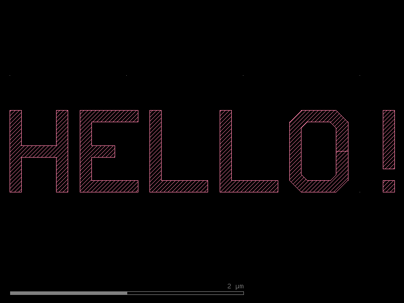

```python
r = kf.kdb.DBox(-2.5, -5, 2.5, 5)
r
```

r = kf.kdb.DBox(-2.5, -5, 2.5, 5) r

```
(-2.5,-5;2.5,5)
```

Add instances to the new geometry to c, our blank cell

```python
c = kf.KCell()
c.shapes(c.kcl.find_layer(1, 0)).insert(r)
c.shapes(c.kcl.find_layer(2, 0)).insert(r)
c
```

c = kf.KCell() c.shapes(c.kcl.find_layer(1, 0)).insert(r) c.shapes(c.kcl.find_layer(2, 0)).insert(r) c

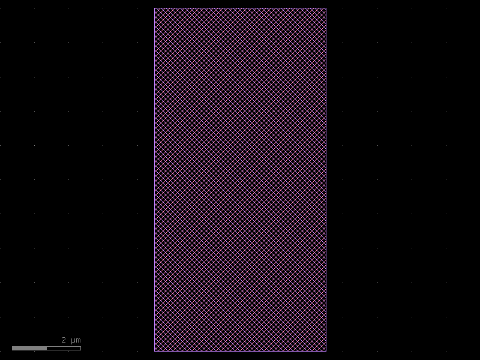

```python
c = kf.KCell()
textgenerator = kf.kdb.TextGenerator.default_generator()
text1 = t.transformed(
    kf.kdb.DTrans(0.0, 10.0).to_itype(c.kcl.dbu)
)  # DTrans is a transformation in microns with arguments (<rotation in 90° increments>, <mirror boolean>, <x in microns>, <y in microns>)
# Now that the geometry has been added to "c", we can move everything around:
```

c = kf.KCell() textgenerator = kf.kdb.TextGenerator.default_generator() text1 = t.transformed( kf.kdb.DTrans(0.0, 10.0).to_itype(c.kcl.dbu) ) # DTrans is a transformation in microns with arguments (, , , ) # Now that the geometry has been added to "c", we can move everything around:

```python
### complex transformation example:ce
#     magnification(float): magnification, DO NOT USE on cells or instances, only on shapes. Most foundries will not allow magnifications on actual cell instances or cells.
#     rotation(float): rotation in degrees
#     mirror(bool): boolean to mirror at x axis and then rotate if true
#     x(float): x coordinate
#     y(float): y coordinate
#
text2 = t.transformed(
    kf.kdb.DCplxTrans(2.0, 45.0, False, 5.0, 30.0).to_itrans(c.kcl.dbu)
)
# text1.movey(25)
# text2.move([5, 30])
# text2.rotate(45)
r.move(
    -5, 0
)  # boxes can be moved like this, other shapes and cells/refs need to be moved with .transform
r.move(-5, 0)
```

### complex transformation example:ce # magnification(float): magnification, DO NOT USE on cells or instances, only on shapes. Most foundries will not allow magnifications on actual cell instances or cells. # rotation(float): rotation in degrees # mirror(bool): boolean to mirror at x axis and then rotate if true # x(float): x coordinate # y(float): y coordinate # text2 = t.transformed( kf.kdb.DCplxTrans(2.0, 45.0, False, 5.0, 30.0).to_itrans(c.kcl.dbu) ) # text1.movey(25) # text2.move([5, 30]) # text2.rotate(45) r.move( -5, 0 ) # boxes can be moved like this, other shapes and cells/refs need to be moved with .transform r.move(-5, 0)

```
(-12.5,-5;-7.5,5)
```

```python
c.shapes(c.kcl.find_layer(1, 0)).insert(text1)
c.shapes(c.kcl.find_layer(2, 0)).insert(text2)
c.shapes(c.kcl.find_layer(2, 0)).insert(r)
```

c.shapes(c.kcl.find_layer(1, 0)).insert(text1) c.shapes(c.kcl.find_layer(2, 0)).insert(text2) c.shapes(c.kcl.find_layer(2, 0)).insert(r)

```
box (-12500,-5000;-7500,5000)
```

```python
c.show()  # show in KLayout
c.plot()
```

c.show() # show in KLayout c.plot()

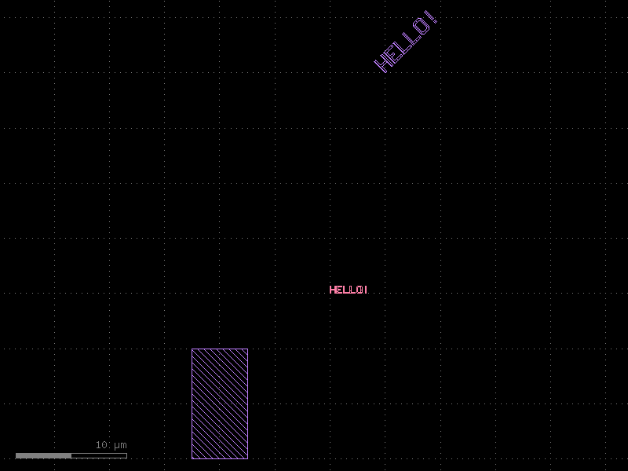

This portion essentially demonstrates how to draw a shape and add connections to it.

It defines a function named straight, which accepts the following three arguments: Length: The length of a waveguide in microns, the default is 10 µm. Width: The width of the waveguide in microns, the default is 1 µm. Layer: A tuple (data structure with multiple parts to it), which specifies the GDSII (Graphic Design System II) layer it will draw on. layer=(1, 0): This tuple holds the blueprint information. *layer: The asterisk * is Python's "unpacking" operator. It turns the tuple (1, 0) into two separate arguments, so kf.kcl.find_layer(*layer) is the same as calling kf.kcl.find_layer(1, 0). kf.kcl.find_layer: This function takes the layer and purpose numbers, in this case 1 and 0 and finds the corresponding internal layer index. This will then allow the KLayout software uses to manage the data efficiently. wg.shapes(_layer).insert(box): This is the "drawing" step. It instructs the software to take the rectangular box shape and place it specifically on the blueprint for Layer 1, Purpose 0. Without this, the shape would exist only in memory but not be part of the final chip design. wg = kf.KCell(): Creates a new, empty cell named wg (short for waveguide). box = kf.kdb.DBox(length, width): Creates a rectangular shape object using floating-point coordinates in microns. int_box = wg.kcl.to_dbu(box): Chip layout databases use integers for high precision, called database units (dbu). This line converts the box's micron coordinates into these integer units. Then the function adds connecting ports named "o1" and "o2". Finally, the function will return the completed wg cell, which now contains the rectangular shape.

```python
@kf.cell
def straight(length=10, width=1, layer=(1, 0)) -> kf.KCell:
    wg = kf.KCell()
    box = kf.kdb.DBox(length, width)
    int_box = wg.kcl.to_dbu(box)
    _layer = kf.kcl.find_layer(*layer)
    wg.shapes(_layer).insert(box)
    wg.add_port(
        port=kf.Port(
            name="o1",
            width=wg.kcl.to_dbu(width),
            dcplx_trans=kf.kdb.DCplxTrans(1, 180, False, box.left, box.center().y),
            layer=_layer,
        )
    )
    wg.create_port(
        name="o2",
        trans=kf.kdb.Trans(int_box.right, int_box.center().y),
        layer=_layer,
        width=int_box.height(),
    )
    return wg

# The following code creates and places three separate straight waveguides, each with a different length, into a designated cell called c.
```

@kf.cell def straight(length=10, width=1, layer=(1, 0)) -> kf.KCell: wg = kf.KCell() box = kf.kdb.DBox(length, width) int_box = wg.kcl.to_dbu(box) _layer = kf.kcl.find_layer(*layer) wg.shapes(_layer).insert(box) wg.add_port( port=kf.Port( name="o1", width=wg.kcl.to_dbu(width), dcplx_trans=kf.kdb.DCplxTrans(1, 180, False, box.left, box.center().y), layer=_layer, ) ) wg.create_port( name="o2", trans=kf.kdb.Trans(int_box.right, int_box.center().y), layer=_layer, width=int_box.height(), ) return wg # The following code creates and places three separate straight waveguides, each with a different length, into a designated cell called c.

```python
c = kf.KCell()
wg1 = c << straight(length=1, width=2.5, layer=(1, 0))
wg2 = c << straight(length=2, width=2.5, layer=(1, 0))
wg3 = c << straight(length=3, width=2.5, layer=(1, 0))
c
```

c = kf.KCell() wg1 = c << straight(length=1, width=2.5, layer=(1, 0)) wg2 = c << straight(length=2, width=2.5, layer=(1, 0)) wg3 = c << straight(length=3, width=2.5, layer=(1, 0)) c

[figure not shown]

Each straight has two ports: 'o1' and 'o2'. These are arbitrary names defined in our straight() function above

```python
# Let us keep wg1 in place on the bottom and then connect the other straights to it.
# To do that, on wg2 we will grab the "W0" port and connect it to the "E0" on wg1:
wg2.connect("o1", wg1.ports["o2"])
# Next, on wg3, take the "W0" port and connect it to the "E0" on wg2:
wg3.connect("o1", wg2.ports["o2"])
c
```

# Let us keep wg1 in place on the bottom and then connect the other straights to it. # To do that, on wg2 we will grab the "W0" port and connect it to the "E0" on wg1: wg2.connect("o1", wg1.ports["o2"]) # Next, on wg3, take the "W0" port and connect it to the "E0" on wg2: wg3.connect("o1", wg2.ports["o2"]) c

[figure not shown]

```python
c.add_port(name="o1", port=wg1.ports["o1"])
c.add_port(name="o2", port=wg3.ports["o2"])
c.show()  # show in KLayout
c.plot()
```

c.add_port(name="o1", port=wg1.ports["o1"]) c.add_port(name="o2", port=wg3.ports["o2"]) c.show() # show in KLayout c.plot()

[figure not shown]